# Analiza danych - ZED

Rafal Chmara

18 grudnia 2016

# 1 Wprowadzenie

Celem projektu jest analiza zbioru danych dotyczących połowu śledzia oceanicznego w Europie oraz próba określenia głównych przyczyn stopniowego zmniejszania się długości śledzi. Pomiary zawierają obserwacje z ostatnich 60 lat. Wiersze są uporządkowane chronologicznie.

Zbiór danych zawiera 52582 obserwacji opisanych 16 cechami.

# 2 Podsumowanie analizy

- wzrost temperatury wskutek dodatniej fazy oscylacji północnoatlantyckiej
- spadek dostępności pożywienia
- spadek liczby małych ryb (narybku)

# 3 Ładowanie oraz struktura danych

```r
#load libraries
library(knitr)       # report generation
library(dplyr)       # data manipulation
library(ggplot2)     # plots visualisation
library(gridExtra)   # multiple plots on grid
library(corrplot)    # correlation matrix visualisation
library(plotly)      # interactive plots
library(caret)       # data exploration lib
library(randomForest)# rf
```

```r
rawCSV <- read.csv("sledzie.csv", na.strings = "?")
str(rawCSV)
```

```
## 'data.frame':    52582 obs. of  16 variables:
##  $ X     : int  0 1 2 3 4 5 6 7 8 9 ...
##  $ length: num  23 22.5 25 25.5 24 22 24 23.5 22.5 22.5 ...
##  $ cfin1 : num  0.0278 0.0278 0.0278 0.0278 0.0278 ...
##  $ cfin2 : num  0.278 0.278 0.278 0.278 0.278 ...
##  $ chel1 : num  2.47 2.47 2.47 2.47 2.47 ...
##  $ chel2 : num  NA 21.4 21.4 21.4 21.4 ...
##  $ lcop1 : num  2.55 2.55 2.55 2.55 2.55 ...
##  $ lcop2 : num  26.4 26.4 26.4 26.4 26.4 ...
##  $ fbar  : num  0.356 0.356 0.356 0.356 0.356 0.356 0.356 0.356 0.356 0.356 ...
##  $ recr  : int  482831 482831 482831 482831 482831 482831 482831 482831 482831 482831 ...
##  $ cumf  : num  0.306 0.306 0.306 0.306 0.306 ...
##  $ totaln: num  267381 267381 267381 267381 267381 ...
##  $ sst   : num  14.3 14.3 14.3 14.3 14.3 ...
##  $ sal   : num  35.5 35.5 35.5 35.5 35.5 ...
##  $ xmonth: int  7 7 7 7 7 7 7 7 7 7 ...
##  $ nao   : num  2.8 2.8 2.8 2.8 2.8 2.8 2.8 2.8 2.8 2.8 ...
```

Zbiór danych zawiera 52582 obserwacje opisane 16 atrybutami:

| Nazwa atrybutu | Opis |
| --- | --- |
| length | długość złowionego śledzia [cm] |
| cfin1 | dostępność planktonu [zagęszczenie Calanus finmarchicus gat. 1] |
| cfin2 | dostępność planktonu [zagęszczenie Calanus finmarchicus gat. 2] |
| chel1 | dostępność planktonu [zagęszczenie Calanus helgolandicus gat. 1] |
| chel2 | dostępność planktonu [zagęszczenie Calanus helgolandicus gat. 2] |
| lcop1 | dostępność planktonu [zagęszczenie widłonogów gat. 1] |
| lcop2 | dostępność planktonu [zagęszczenie widłonogów gat. 2] |
| fbar | natężenie połowów w regionie [ułamek pozostawionego narybku] |
| recr | roczny narybek [liczba śledzi] |
| cumf | łączne roczne natężenie połowów w regionie [ułamek pozostawionego narybku] |
| totaln | łączna liczba ryb złowionych w ramach połowu [liczba śledzi] |
| sst | temperatura przy powierzchni wody [°C] |
| sal | poziom zasolenia wody [Knudsen ppt] |
| xmonth | miesiąc połowu [numer miesiąca] |
| nao | oscylacja północnoatlantycka [mb] |

# 4 Analiza rozkładu atrybutów

Krótkie podsumowanie statystyk wartości atrybutów:

```r
summary(rawCSV[-1])
```

```
##      length         cfin1             cfin2             chel1
##  Min.   :19.0   Min.   : 0.0000   Min.   : 0.0000   Min.   : 0.000
##  1st Qu.:24.0   1st Qu.: 0.0000   1st Qu.: 0.2778   1st Qu.: 2.469
##  Median :25.5   Median : 0.1111   Median : 0.7012   Median : 5.750
##  Mean   :25.3   Mean   : 0.4458   Mean   : 2.0248   Mean   :10.006
##  3rd Qu.:26.5   3rd Qu.: 0.3333   3rd Qu.: 1.7936   3rd Qu.:11.500
##  Max.   :32.5   Max.   :37.6667   Max.   :19.3958   Max.   :75.000
##                 NA's   :1581      NA's   :1536      NA's   :1555
##      chel2            lcop1              lcop2             fbar
##  Min.   : 5.238   Min.   :  0.3074   Min.   : 7.849   Min.   :0.0680
##  1st Qu.:13.427   1st Qu.:  2.5479   1st Qu.:17.808   1st Qu.:0.2270
##  Median :21.673   Median :  7.0000   Median :24.859   Median :0.3320
##  Mean   :21.221   Mean   : 12.8108   Mean   :28.419   Mean   :0.3304
##  3rd Qu.:27.193   3rd Qu.: 21.2315   3rd Qu.:37.232   3rd Qu.:0.4560
##  Max.   :57.706   Max.   :115.5833   Max.   :68.736   Max.   :0.8490
##  NA's   :1556     NA's   :1653       NA's   :1591
##       recr              cumf             totaln             sst
##  Min.   : 140515   Min.   :0.06833   Min.   : 144137   Min.   :12.77
##  1st Qu.: 360061   1st Qu.:0.14809   1st Qu.: 306068   1st Qu.:13.60
##  Median : 421391   Median :0.23191   Median : 539558   Median :13.86
##  Mean   : 520367   Mean   :0.22981   Mean   : 514973   Mean   :13.87
##  3rd Qu.: 724151   3rd Qu.:0.29803   3rd Qu.: 730351   3rd Qu.:14.16
##  Max.   :1565890   Max.   :0.39801   Max.   :1015595   Max.   :14.73
##                                                        NA's   :1584
##       sal            xmonth            nao
##  Min.   :35.40   Min.   : 1.000   Min.   :-4.89000
##  1st Qu.:35.51   1st Qu.: 5.000   1st Qu.:-1.89000
##  Median :35.51   Median : 8.000   Median : 0.20000
##  Mean   :35.51   Mean   : 7.258   Mean   :-0.09236
##  3rd Qu.:35.52   3rd Qu.: 9.000   3rd Qu.: 1.63000
##  Max.   :35.61   Max.   :12.000   Max.   : 5.08000
##
```

# 5 Wartości puste

Zbiór danych opisujący połów śledzi zawiera 10094 niepełnych obserwacji. Cały zbiór składa się z jedynie 52582 pomiarów, odrzucając tak dużą część danych zostałyby utracone istotne informacje.

Na podstawie podsumowania statystyk kolejnych atrybutów można zauważyć, że brakujące wartości występują jedynie w cechach opisujących:

- dostępność planktonu (cfin1, cfin2, chel1, chel2, lcop1, lcop2),
- temperaturę przy powierzchni wody (sst).

W zbiorze danych warto zwrócić uwagę, że wartości atrybutów najczęściej występują w podobnych grupach. Dla przedstawienia tej zależności wybrano przykładowe trzy podzbiory sąsiadujących ze sobą elementów:

```r
rawCSV[c(1:5, 1001:1005, 20001:20005), ]
```

```
##           X length   cfin1    cfin2    chel1    chel2    lcop1    lcop2
## 1         0   23.0 0.02778  0.27785  2.46875       NA  2.54787 26.35881
## 2         1   22.5 0.02778  0.27785  2.46875 21.43548  2.54787 26.35881
## 3         2   25.0 0.02778  0.27785  2.46875 21.43548  2.54787 26.35881
## 4         3   25.5 0.02778  0.27785  2.46875 21.43548  2.54787 26.35881
## 5         4   24.0 0.02778  0.27785  2.46875 21.43548  2.54787 26.35881
## 1001   1000   26.5 2.14333  0.29600  6.38667 21.67333  9.01000 24.85867
## 1002   1001   25.0 2.14333  0.29600  6.38667 21.67333  9.01000 24.85867
## 1003   1002   25.5 2.14333  0.29600  6.38667 21.67333  9.01000 24.85867
## 1004   1003   23.5 2.14333  0.29600  6.38667 21.67333       NA 24.85867
## 1005   1004   24.5 2.14333  4.45882  6.38667 26.17187  9.01000 32.19090
## 20001 20000   26.0 0.20536 19.39583       NA 32.64940 11.77679 65.51964
## 20002 20001   28.0 0.20536 19.39583 11.24554 32.64940 11.77679 65.51964
## 20003 20002   26.0 0.20536 19.39583 11.24554 32.64940 11.77679 65.51964
## 20004 20003   25.5 0.20536 19.39583 11.24554 32.64940 11.77679 65.51964
```

[output cut: 17 more lines]

Widać wyraźnie, że sąsiadujące ze sobą elementy mają prawie zawsze identyczne wartości na atrybutach cfin1, cfin2, chel1, chel2, lcop1, lcop2, fbar, recr, cumf, totaln, sst, sal, xmonth, nao, a różnice są niewielkie. W pierwszej obserwacji (X=1) cechę ‘chel2’, na pierwszy rzut oka, możnaby uzupełnić o wartość 21.43548. Podobnie w 1004 wierszu lcop na 9.01000 itd.

Do uzupełnienia wartości pustych wybrane zostaną wiersze posiadające grupy podobne do uzupełnianego wiersza. Następnie z podobnych grup wyznaczona zostanie mediana dla danej wartości.

```r
#Uproszczony algorytm wyznaczania grup podobnych i mediany do uzupełnienia wartości pustych (przykład dla atrybutu sst)
df <- rawCSV[is.na(rawCSV$sst), ]
for(i in 1:nrow(df)){
  row <- df[i,]
  #wyznaczanie grup podobnych na podstawie atrybutów totaln, sal, xmonth oraz nao
  similarGroups <- rawCSV[
      rawCSV$totaln == row$totaln &
      rawCSV$sal == row$sal &
      rawCSV$xmonth == row$xmonth &
      rawCSV$nao == row$nao, ]
  #przypisanie mediany
  df[i,]$sst <- median(similarGroups$sst, na.rm = TRUE)
}
```

Statystyki zbioru po wypełnieniu wartości pustych:

```r
summary(withoutMissing[-1])
```

```
##      length         cfin1             cfin2             chel1
##  Min.   :19.0   Min.   : 0.0000   Min.   : 0.0000   Min.   : 0.000
##  1st Qu.:24.0   1st Qu.: 0.0000   1st Qu.: 0.2778   1st Qu.: 2.469
##  Median :25.5   Median : 0.1111   Median : 0.7012   Median : 5.750
##  Mean   :25.3   Mean   : 0.4439   Mean   : 2.0261   Mean   : 9.960
##  3rd Qu.:26.5   3rd Qu.: 0.3333   3rd Qu.: 1.7936   3rd Qu.:11.500
##  Max.   :32.5   Max.   :37.6667   Max.   :19.3958   Max.   :75.000
##      chel2            lcop1              lcop2             fbar
##  Min.   : 5.238   Min.   :  0.3074   Min.   : 7.849   Min.   :0.0680
##  1st Qu.:13.589   1st Qu.:  2.5479   1st Qu.:17.808   1st Qu.:0.2270
##  Median :21.673   Median :  7.0717   Median :24.859   Median :0.3320
##  Mean   :21.209   Mean   : 12.7327   Mean   :28.417   Mean   :0.3304
##  3rd Qu.:27.193   3rd Qu.: 21.2315   3rd Qu.:37.232   3rd Qu.:0.4560
##  Max.   :57.706   Max.   :115.5833   Max.   :68.736   Max.   :0.8490
##       recr              cumf             totaln             sst
##  Min.   : 140515   Min.   :0.06833   Min.   : 144137   Min.   :12.77
##  1st Qu.: 360061   1st Qu.:0.14809   1st Qu.: 306068   1st Qu.:13.60
##  Median : 421391   Median :0.23191   Median : 539558   Median :13.86
##  Mean   : 520367   Mean   :0.22981   Mean   : 514973   Mean   :13.87
##  3rd Qu.: 724151   3rd Qu.:0.29803   3rd Qu.: 730351   3rd Qu.:14.16
##  Max.   :1565890   Max.   :0.39801   Max.   :1015595   Max.   :14.73
##       sal            xmonth            nao
##  Min.   :35.40   Min.   : 1.000   Min.   :-4.89000
##  1st Qu.:35.51   1st Qu.: 5.000   1st Qu.:-1.89000
##  Median :35.51   Median : 8.000   Median : 0.20000
##  Mean   :35.51   Mean   : 7.258   Mean   :-0.09236
##  3rd Qu.:35.52   3rd Qu.: 9.000   3rd Qu.: 1.63000
##  Max.   :35.61   Max.   :12.000   Max.   : 5.08000
```

# 6 Analiza wartości atrybutów

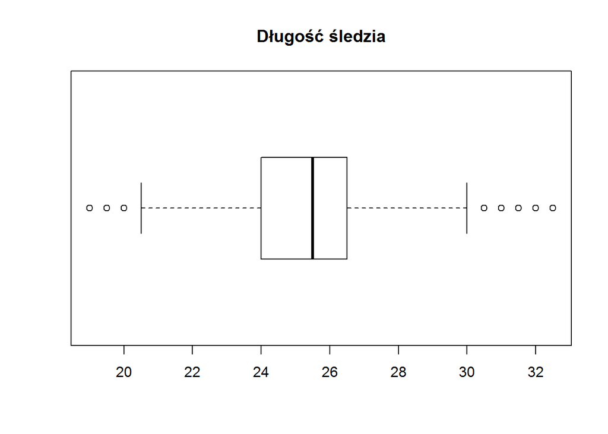

```r
boxplot(withoutMissing$length, horizontal=TRUE, main="Długość śledzia")
```

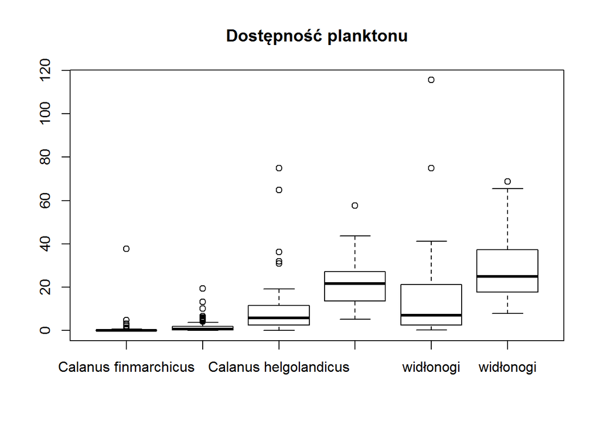

```r
boxplot(withoutMissing[,3:8], main="Dostępność planktonu",
        names=c("Calanus finmarchicus", "Calanus finmarchicus", "Calanus helgolandicus", "Calanus helgolandicus", "widłonogi", "widłonogi"))
```

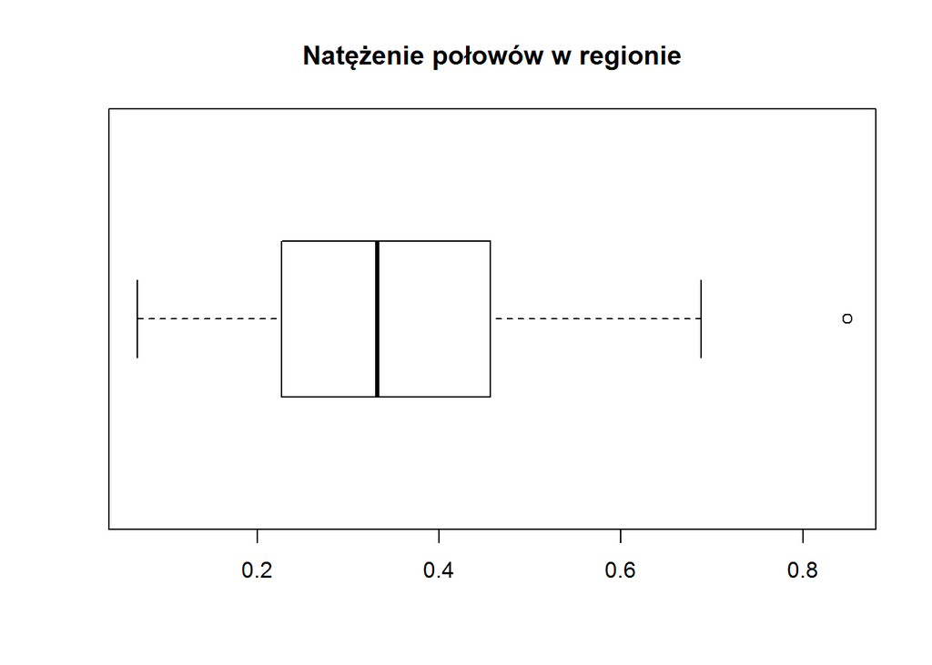

```r
boxplot(withoutMissing$fbar, horizontal=TRUE, main="Natężenie połowów w regionie")
```

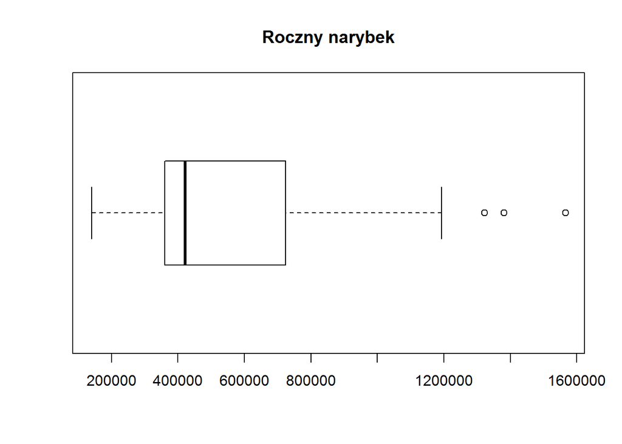

```r
boxplot(withoutMissing$recr, horizontal=TRUE, main="Roczny narybek")
```

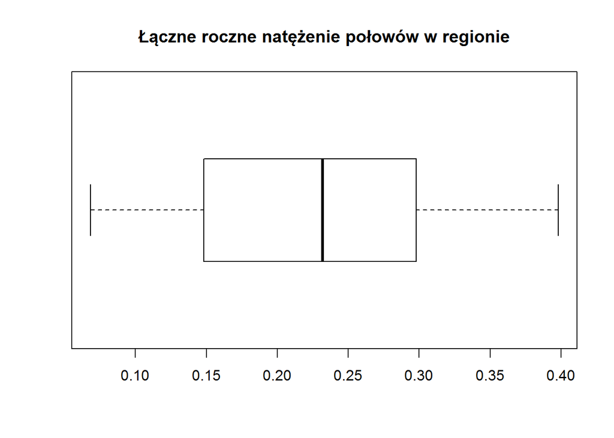

```r
boxplot(withoutMissing$cumf, horizontal=TRUE, main="Łączne roczne natężenie połowów w regionie")
```

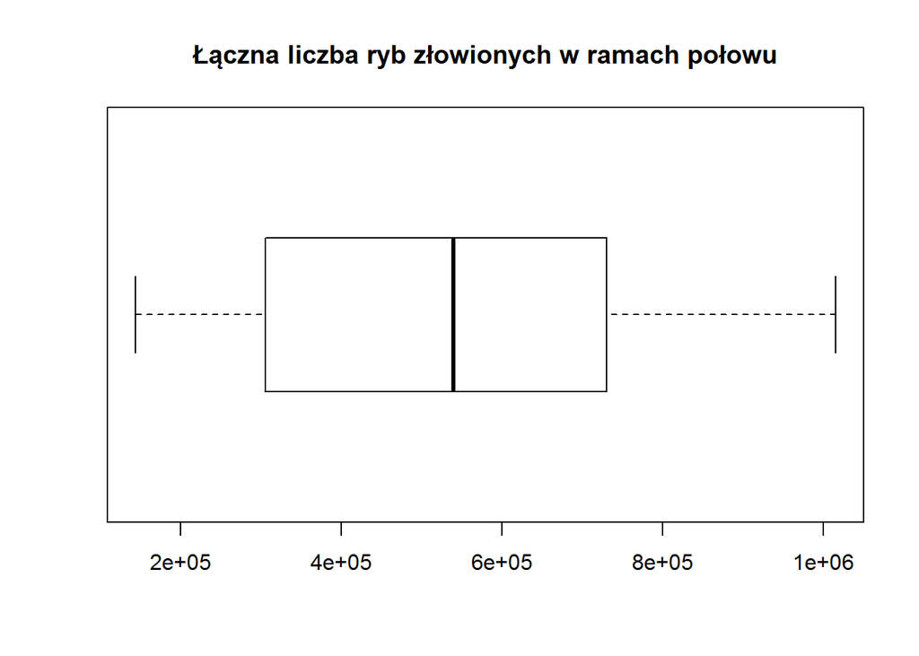

```r
boxplot(withoutMissing$totaln, horizontal=TRUE, main="Łączna liczba ryb złowionych w ramach połowu")
```

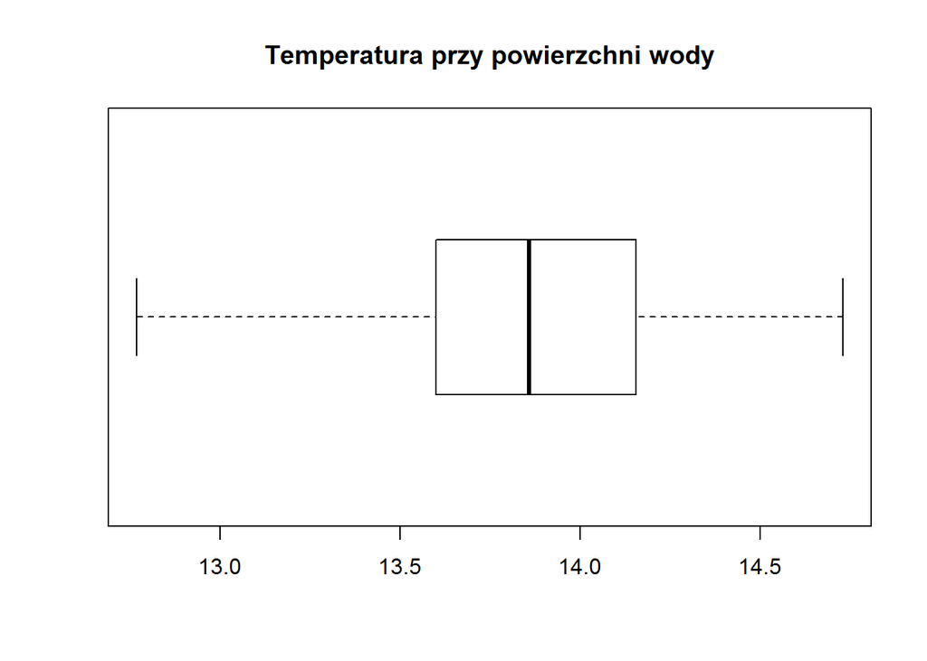

```r
boxplot(withoutMissing$sst, horizontal=TRUE, main="Temperatura przy powierzchni wody")
```

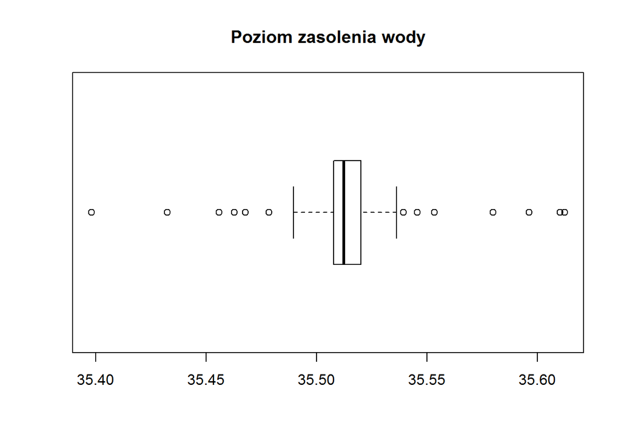

```r
boxplot(withoutMissing$sal, horizontal=TRUE, main="Poziom zasolenia wody")
```

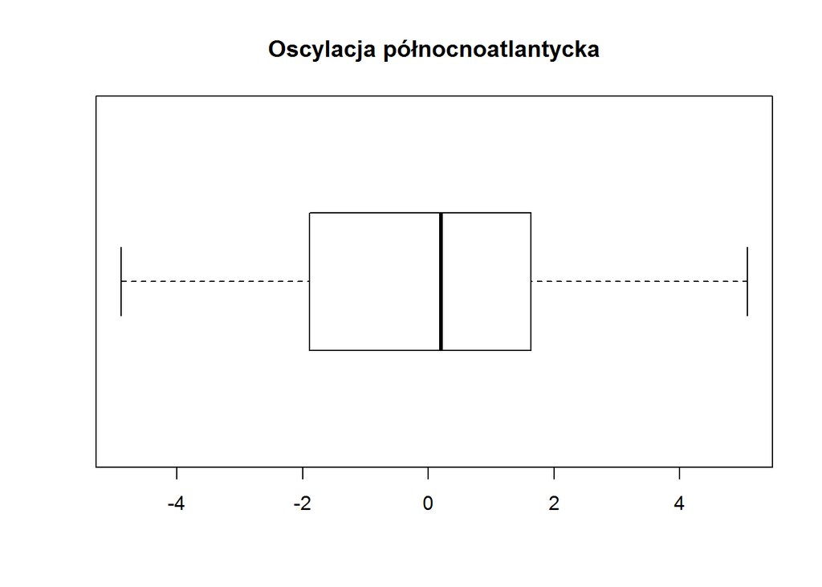

```r
boxplot(withoutMissing$nao, horizontal=TRUE, main="Oscylacja północnoatlantycka")
```

# 7 Analiza korelacji

Analizę związków pomiędzy atrybutami dokonano za pomocą wizualizacji macierzy korelacji.

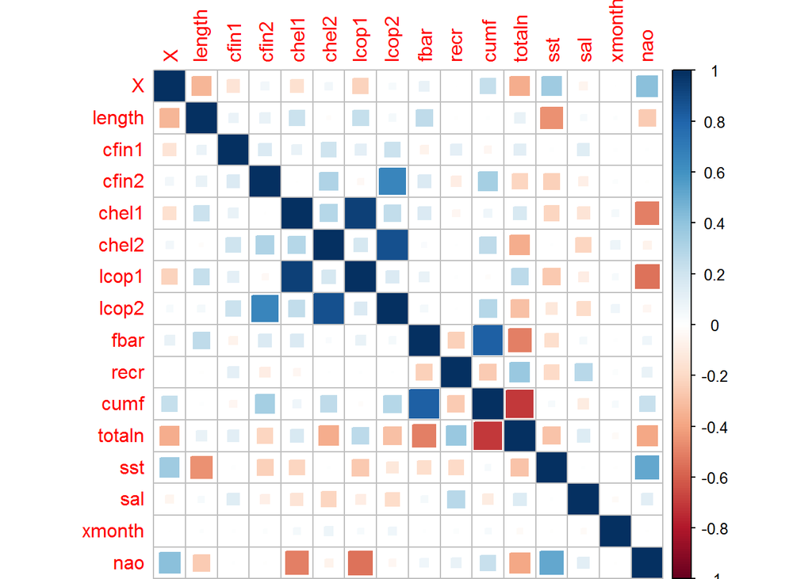

```r
corMatrix <- cor(withoutMissing)
corrplot(corMatrix, method = "square")
```

Na wykresie można zauważyć silną korelację ujemną między długością śledzia (length), a temperaturą przy powierzchni (sst). Wielkość ryb zależy również od oscylacji północnoatlantyckiej (nao).

Oscylacja Północnoatlantycka to zjawisko meteorologiczne, które ma wpływ na klimat i jest związane ze zmianami cyrkulacji powietrza i wód, ze zmianami ciśnienia oraz temperatury. Można to zauważyć na macierzy - temperatura przy powierzchni jest silnie dodatnio skorelowana z NAO. Ujemna korelacja oznacza, że wyższa temperatura oraz dodatnia faza NAO wpływa na zmiejszenie się długości łowionych śledzi.

Rozmiar śledzia jest także skorelowany z intensywnościa połowów oraz dostępnością planktonu (chel1 - Calanus helgolandicus gat. 1 i lcop1 - widłonogów gat. 1).

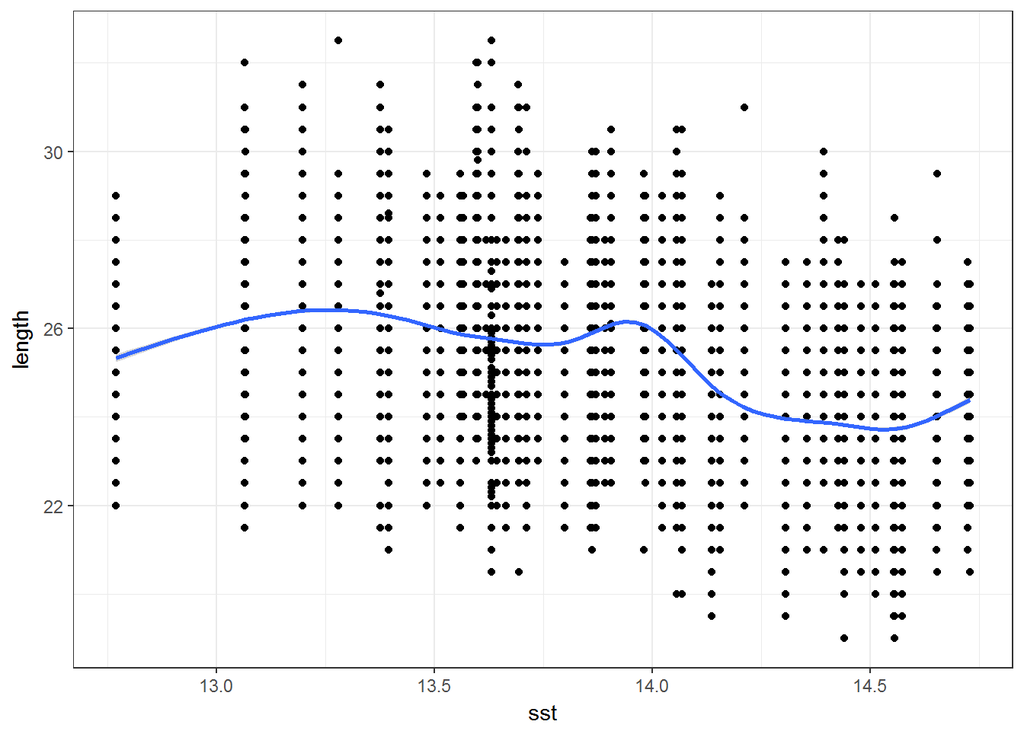

```r
ggplot(withoutMissing, aes(x=sst, y=length)) + geom_point() + geom_smooth() + theme_bw()
```

# 8 Prezentacja zmiany rozmiaru śledzi w czasie

Dane w zbiorze są uporządkowane chronolicznie, dlatego jako atrybut X zostanie przedstawiony jako zmiana czasu. Do prezentacji wybrano próbkę 5% ze zbioru, aby wykres interaktywny działał w sposób płynny.

```r
partition <- createDataPartition(y=withoutMissing$length, p=.05, list=FALSE)
dfPartition <- withoutMissing[partition, ]
p <- ggplot(dfPartition, aes(x=X, y=length)) + geom_point() + geom_smooth() + theme_bw()
ggplotly(p)
```

[interactive chart not shown]

# 9 Regresor przewidujący rozmiar śledzia

W kolejnym kroku dane zostaną podzielone na dane treningowe 80% i testowe 20% za pomocą stratyfikacji. Do utworzenia modelu wykorzystany zostanie algorytm Random Forest (RF). Podczas trenowania regresora wykorzystana zostanie metoda ‘repeatedcv’ podziału zbioru. Uczenie będzie miało zadanie wybrać optymalny parametr mtry dla algorytmu RF na podstawie miary RMSE.

```r
#Podział zbioru na dane uczące 80%, testowe 20%
set.seed(69)
afterFeatureSelection <- withoutMissing %>% select(length, cfin1, cfin2, chel1, chel2, lcop1, lcop2, fbar, recr, cumf, totaln, sst, sal, nao)
regPartition <- createDataPartition(y=afterFeatureSelection$length, p=.8, list=FALSE)
train <- afterFeatureSelection[regPartition, ]
test <- afterFeatureSelection[-regPartition, ]
print(5)
```

```
## [1] 5
```

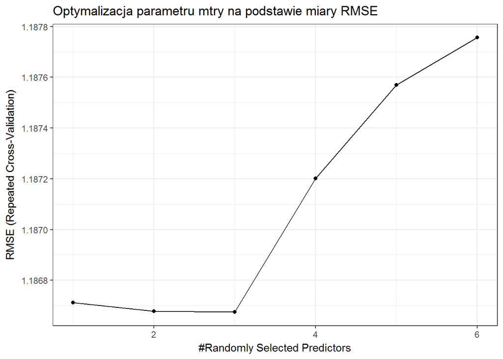

```r
rfGrid <- expand.grid(mtry = 1:6)
#Schemat uczenia rcv
ctrl <- trainControl(
    method = "repeatedcv",
    number = 5,
    repeats = 2)

#uczenie
fit <- train(length ~ .,
             data = train,
             method = 'rf',
             trControl = ctrl,
             metric = "RMSE",
             tuneGrid=rfGrid,
             importance = TRUE,
             ntree=20)
ggplot(fit) + ggtitle("Optymalizacja parametru mtry na podstawie miary RMSE") + theme_bw()
```

Jak widać na powyższym wykresie biblioteka caret dobrała optymalną wartość parametru mtry, dla algorytmu RandomForest, równą 3.

Testowanie wygenerowanego modelu na danych testowych:

```r
predictions <- predict(fit, newdata = test[-1])
modelValues <- data.frame(obs = test$length, pred = predictions)
```

Model regresyjny został poddany testom na danych testowych. Osiągnięto wynik w postaci miar RMSE i Rsquared:

| RMSE | 1.1943293 |
| --- | --- |
| Rsquared | 0.4829774 |

# 10 Analiza ważności atrybutów

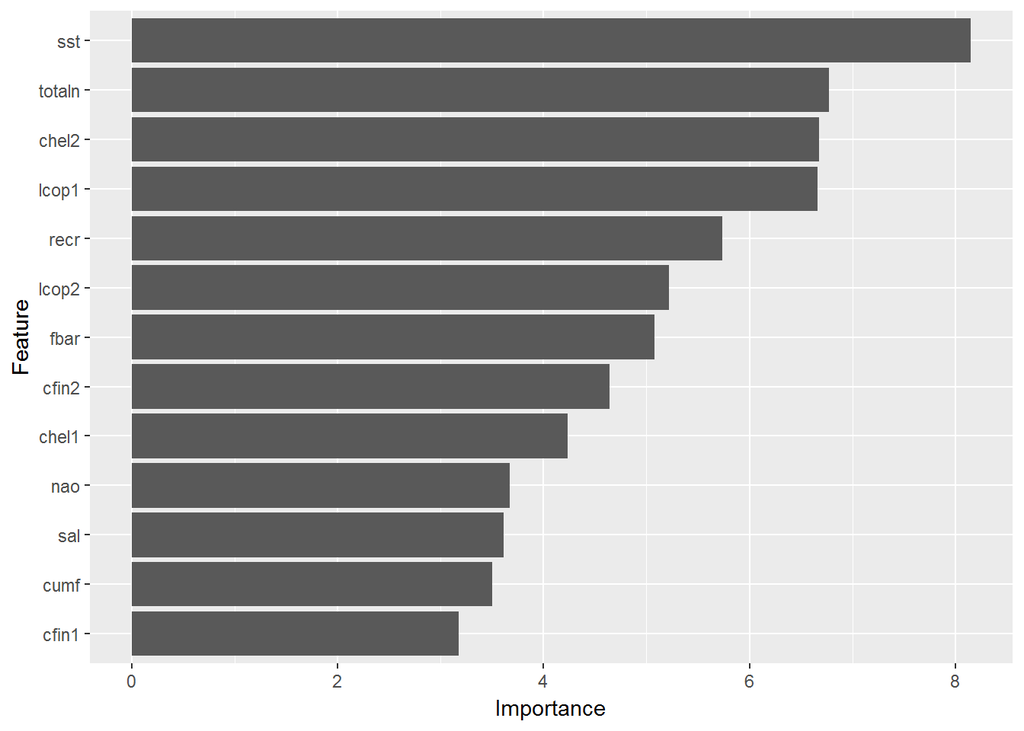

```r
importance <- varImp(fit, scale = FALSE)
ggplot(importance)
```

Analiza ważności atrybutów wskazuje, że najważniejszym atrybutem podczas predykcji była temperatura przy powierzchni wody (sst). Wspomniany w jednym z poprzednich punktów atrybut dotyczący oscylacji północnoatlantyckiej nie jest tak ważny dla predykcji, bo jest silnie skorelowany z sst. Drugą cechą pod względem ważności mającą wpływ na predykcję wielkości śledzia okazała się cecha totaln - liczba śledzi złowionych podczas połowu. Kolejnymi atrybutami pod względem wagi przy predykcji to gatunki planktonu (chel2, lcop1), a także roczny narybek.

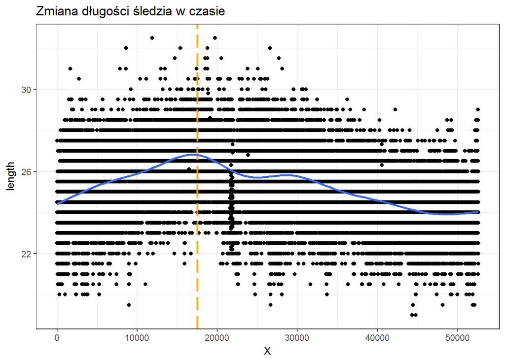

```r
ggplot(data= withoutMissing, aes(x=X,y=length)) + geom_point() + geom_vline(xintercept = 17500, color="orange", linetype = "longdash", size = 1) + geom_smooth() + ggtitle("Zmiana długości śledzia w czasie") + theme_bw()
```

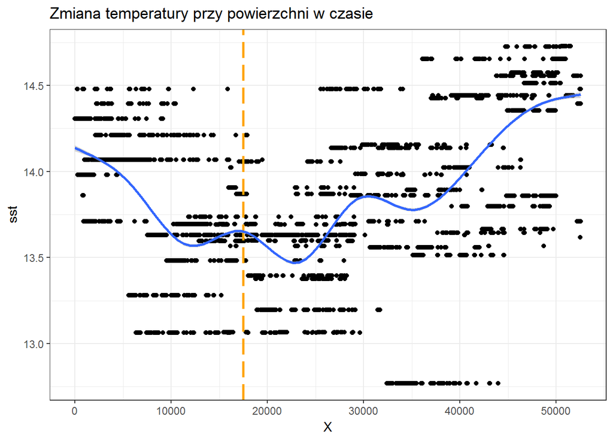

```r
ggplot(data= withoutMissing, aes(x=X,y=sst)) + geom_point() + geom_vline(xintercept = 17500, color="orange", linetype = "longdash", size = 1) + geom_smooth() + ggtitle("Zmiana temperatury przy powierzchni w czasie") + theme_bw()
```

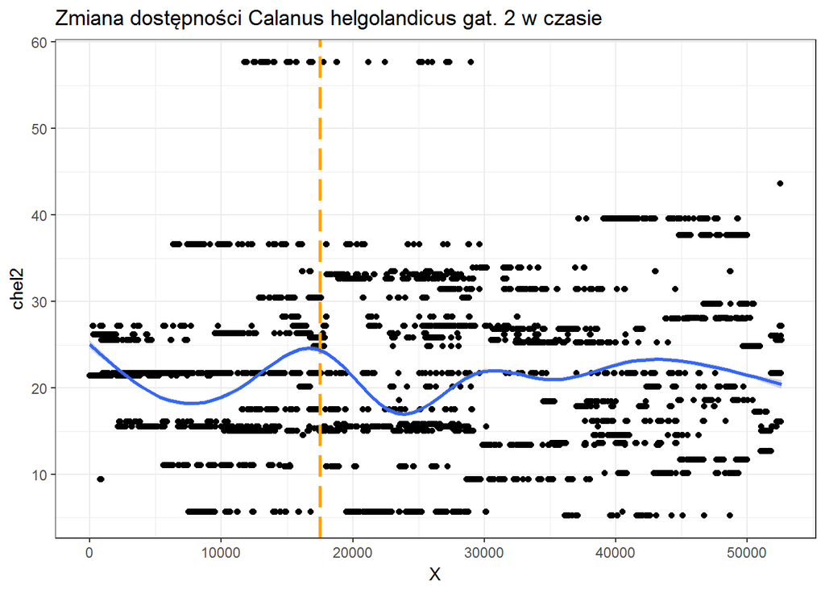

```r
ggplot(data= withoutMissing, aes(x=X,y=chel2)) + geom_point() + geom_vline(xintercept = 17500, color="orange", linetype = "longdash", size = 1) + geom_smooth() + ggtitle("Zmiana dostępności Calanus helgolandicus gat. 2 w czasie") + theme_bw()
```

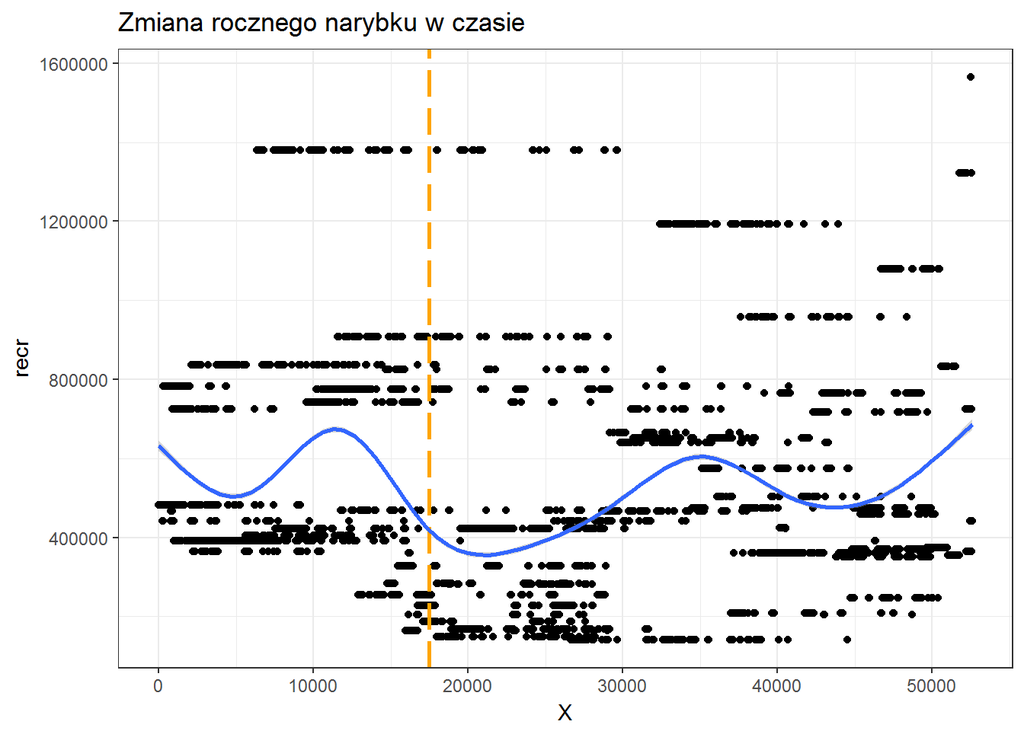

```r
ggplot(data= withoutMissing, aes(x=X,y=recr)) + geom_point() + geom_vline(xintercept = 17500, color="orange", linetype = "longdash", size = 1) + geom_smooth() + ggtitle("Zmiana rocznego narybku w czasie") + theme_bw()
```

Na podstawie powyższych wykresów można zauważyć, że na zmniejszenie długości śledzia mogło mieć wiele równoległych czynników. Widać wyraźnie że jeszcze zanim zaczęto łowić mniejsze śledzie postępował spadek liczności małych ryb (narybku). W tym samym czasie, gdy ryby zaczęły maleć można zauważyć spadek dostępności planktonu - Calanus helgolandicus. Temperatura przy powierzchni wody zaczęła rosnąć dopiero później, jednak mogła mieć wpływ na późniejszy efekt zmniejszenia długości poławianych śledzi.